# Sentiment Analysis on Text data

Uche Kalu

4/17/2022

### Sentiment Analysis on Tweet and Tweet-related information of Apple company

**Sentiment Analysis or Opinion Mining is a Natural Language Processing (NLP) technique that is performed on textual data to help businesses monitor brand and product sentiment in customer feedback, and understand customer needs.**

**It is used to determine whether data is positive, negative or neutral**

### DATA

```r
mydata <- read.table("apple.txt", header = T, sep = ',')

ourdata <- iconv(mydata$text, to = "UTF-8")
```

### Obtain Sentiment scores for each Tweet

**This will classify all the indexed tweets (each tweet will have an index number) among multiple sentiment column that best fits/describes that tweet**

**Lets see the first 6 tweets and their Sentiment scores/values**

```r
s <- get_nrc_sentiment(ourdata)
head(s)
```

```
##   anger anticipation disgust fear joy sadness surprise trust negative positive
## 1     0            0       0    0   0       0        0     0        0        1
## 2     0            0       0    0   0       0        0     0        0        1
## 3     0            0       0    0   0       0        1     0        0        0
## 4     1            0       2    2   0       1        0     0        3        0
## 5     0            0       0    0   0       0        0     0        0        0
## 6     0            0       0    0   0       0        0     0        0        0
```

**Lets see the 4th tweet that contains all this sentiments**

```r
ourdata[4]
```

```
## [1] "RT @SylvaCap: Things might get ugly for $aapl with the iphone delay. With $aapl down that means almost all of the FANG stocks were down posâ\200¦"
```

```r
ourdata[1]
```

```
## [1] "RT @option_snipper: $AAPL beat on both eps and revenues. SEES 4Q REV. $49B-$52B, EST. $49.1B https://t.co/hfHXqj0IOB"
```

**We will classify the stated word - delay (taken from a tweet) among the multiple sentiment column headers that best fits/describes the stated word**

```r
get_nrc_sentiment('delay')
```

```
##   anger anticipation disgust fear joy sadness surprise trust negative positive
## 1     1            0       1    1   0       1        0     0        1        0
```

**We will classify the stated word - ugly (taken from a tweet) among the multiple sentiment column headers that best fits/describes the stated word**

```r
get_nrc_sentiment('ugly')
```

```
##   anger anticipation disgust fear joy sadness surprise trust negative positive
## 1     0            0       1    0   0       0        0     0        1        0
```

### Visualizing the Sentiments Scores

**Create a Bar plot using the Sentiment Scores**

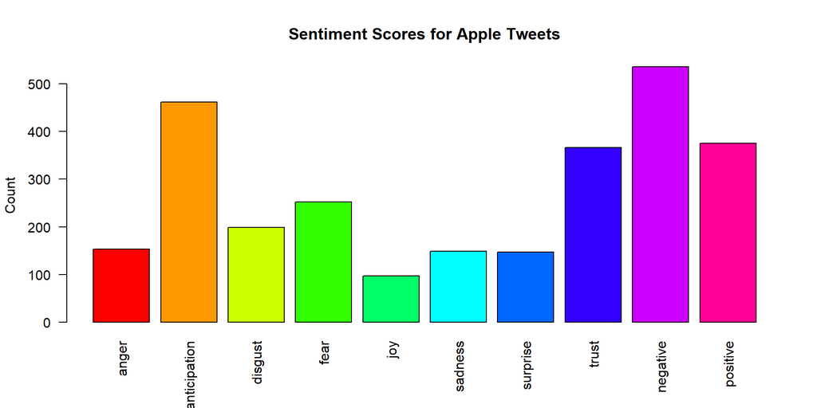

```r
barplot(colSums(s),
        las = 2,
        col = rainbow(10),
        ylab = 'Count',
        main = 'Sentiment Scores for Apple Tweets')
```

**Lets display the Sentiment scores by percentage value**

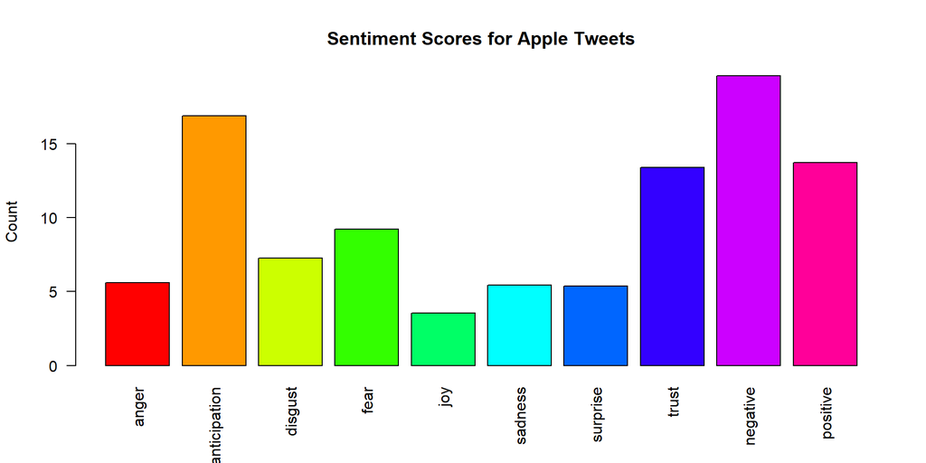

```r
we <- 100*colSums(s)/sum(s)

barplot(we,
        las = 2,
        col = rainbow(10),
        ylab = 'Count',
        main = 'Sentiment Scores for Apple Tweets')
```